# 3. Advanced GWAS Models

This tutorial extends what was previously introduced in the `02_GWAS.Rmd` tutorial to more advanced models using the [GENESIS](https://bioconductor.org/packages/release/bioc/html/GENESIS.html) R/Bioconductor package.

## Sparse Kinship Matrix

Recall that fitting the null model uses a kinship matrix (KM) that captures the genetic correlation among samples. In the `02_GWAS.Rmd` tutorial, we used a dense KM that has non-zero values for all entries in the matrix. This works well with small sample sizes (like we have here), but can require a lot of memory and be very computationally demanding with large samples.

In large population based samples, we can make an empirical KM sparse by zeroing out small values that are near 0. When creating a PC-Relate KM with `pcrelateToMatrix` this can be done by setting the `thresh` parameter equal to the smallest non-zero value to keep in the matrix. Alternatively, we can use the `makeSparseMatrix` function from the GENESIS package to sparsify an existing matrix into a sparse block-diagonal matrix.

```r
repo_path <- "https://github.com/UW-GAC/SISG_2024/raw/main"
if (!dir.exists("data")) dir.create("data")

library(GENESIS)

# load the PC-Relate KM
kmfile <- "data/pcrelate_Matrix.RData"
if (!file.exists(kmfile)) download.file(file.path(repo_path, kmfile), kmfile)
km <- get(load(kmfile))
dim(km)
```

```
## [1] 1040 1040
```

```r
km[1:5,1:5]
```

```
## 5 x 5 Matrix of class "dsyMatrix"
##              HG00096       HG00097      HG00099      HG00100       HG00101
## HG00096  0.985459993  0.0031768617  0.006724604 -0.006857234  0.0060690853
## HG00097  0.003176862  0.9883268089 -0.007300965  0.012888182 -0.0009002438
## HG00099  0.006724604 -0.0073009649  0.976649166  0.022746299  0.0118873586
## HG00100 -0.006857234  0.0128881819  0.022746299  0.978507564  0.0265278283
## HG00101  0.006069085 -0.0009002438  0.011887359  0.026527828  0.9778938334
```

```r
# make the KM sparse at 4th degree relatedness
skm <- makeSparseMatrix(km, thresh = 2*2^(-11/2))
```

```
## Using 1040 samples provided
```

```
## Identifying clusters of relatives...
```

```
##     57 relatives in 26 clusters; largest cluster = 4
```

```
## Creating block matrices for clusters...
```

```
## 983 samples with no relatives included
```

```
## Putting all samples together into one block diagonal matrix
```

```r
dim(skm)
```

```
## [1] 1040 1040
```

```r
skm[1:5,1:5]
```

```
## 5 x 5 sparse Matrix of class "dsCMatrix"
##            HG00112    HG00123   HG00116   HG00120   HG00238
## HG00112 0.98518404 0.09728113 .         .         .
## HG00123 0.09728113 0.98731569 .         .         .
## HG00116 .          .          0.9874224 0.1704253 .
## HG00120 .          .          0.1704253 0.9778078 .
## HG00238 .          .          .         .         0.9927059
```

This sparse KM can be used in the null model in place of the original dense KM that we used in the `02_GWAS.Rmd` tutorial – exercise left to the reader.

## Two Stage Model

As discussed in the lecture, we recommend a fully adjusted two-stage inverse Normalization procedure for fitting the null model for quantitative traits, particularly when the outcome has a non-Normal distribution. See [Sofer et al. (2019)](https://onlinelibrary.wiley.com/doi/10.1002/gepi.22188) for more information on the fully adjusted two-stage model.

### Phenotype Data

First we load the `AnnotatedDataFrame` with the phenotype data that we prepared previously.

```r
library(Biobase)
```

```r
# pheno data
annotfile <- "data/pheno_annotated_pcs.RData"
if (!file.exists(annotfile)) download.file(file.path(repo_path, annotfile), annotfile)
annot <- get(load(annotfile))
head(pData(annot))
```

```
##   sample.id pop super_pop    sex age trait_1 trait_2 status        PC1
## 1   HG00096 GBR       EUR   male  56    23.5     0.1      0 0.01800549
## 2   HG00097 GBR       EUR female  56    23.9     0.1      0 0.01742309
## 3   HG00099 GBR       EUR female  48    23.8     0.3      0 0.01799001
## 4   HG00100 GBR       EUR female  54    24.9     0.2      0 0.01793750
## 5   HG00101 GBR       EUR   male  65    27.6     0.7      1 0.01759459
## 6   HG00102 GBR       EUR female  53    24.5     0.4      0 0.01796459
##           PC2        PC3         PC4           PC5         PC6        PC7
## 1 -0.03361957 0.01541131 -0.02085591 -0.0037719379 -0.04669896 0.01985608
## 2 -0.03361182 0.01304470 -0.01992104 -0.0095947596 -0.04545408 0.01034344
## 3 -0.03418633 0.01152677 -0.01694420  0.0011408340 -0.05178681 0.02212758
## 4 -0.03378008 0.01491137 -0.01954784  0.0045447134 -0.04375806 0.02055287
## 5 -0.03318057 0.01568040 -0.01892110 -0.0009236657 -0.05762760 0.03443987
## 6 -0.03344242 0.01286241 -0.01767438  0.0022747910 -0.06528352 0.03392455
```

For this section of the tutorial, we will be analyzing `trait_2`. Make a histogram of the trait_2 values – what do you notice about the distribution?

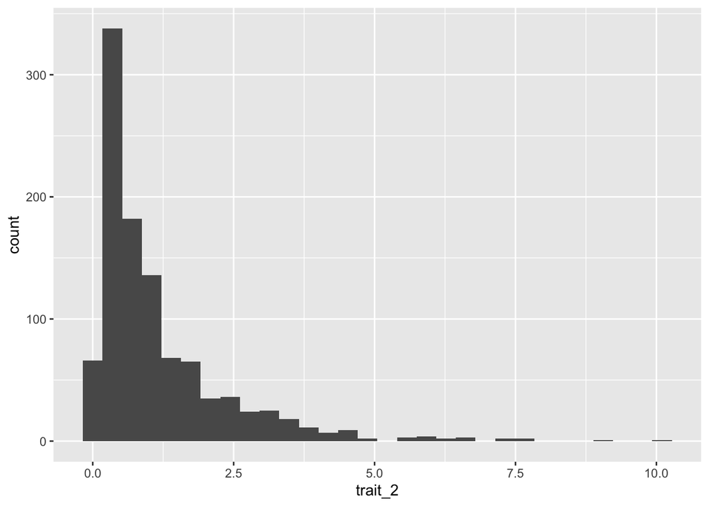

```r
library(ggplot2)
ggplot(pData(annot), aes(x = trait_2)) + geom_histogram()
```

### Standard Analysis

First, let’s run the GWAS using the standard LMM. Recall that we first fit the null model and then perform single variant score tests.

#### Null Model

We use the `fitNullModel` function from GENESIS. We need to specify the `AnnotatedDataFrame` with the phenotype data (annot), the outcome variable (trait_2), and the fixed effect covariates (sex, age, and PCs 1-7). We also include the kinship matrix to specify the covariance structure of the polygenic random effect in the model.

```r
nullmod <- fitNullModel(annot,
                        outcome = "trait_2",
                        covars=c("sex", "age", paste0("PC", c(1:7))),
                        cov.mat=km,
                        verbose=TRUE)
```

```
## Computing Variance Component Estimates...
```

```
## Sigma^2_A     log-lik     RSS
```

```
## [1]     0.7674395     0.7674395 -1642.1166605     0.9161778
## [1]     0.6850887     0.7089644 -1642.1162960     1.0084433
## [1]     0.6923555     0.7134190 -1642.1162873     1.0000701
```

#### Association Tests

After fitting the null model, we use single-variant score tests to test each variant across the genome separately for association with the outcome, accounting for genetic ancestry and genetic relatedness among the samples. Recall that we make a `SeqVarData` iterator object that links the genotype data in the GDS file with the phenotype data in our `AnnotatedDataFrame` and use the `assocTestSingle` function from GENESIS to perform the association tests.

```r
library(SeqVarTools)

# open a connection to the GDS file
gdsfile <- "data/1KG_phase3_GRCh38_subset_chr1.gds"
if (!file.exists(gdsfile)) download.file(file.path(repo_path, gdsfile), gdsfile)
gdsfmt::showfile.gds(closeall=TRUE) # make sure file is not already open
gds <- seqOpen(gdsfile)

# make the seqVarData object
seqData <- SeqVarData(gds, sampleData=annot)

# make the iterator object
iterator <- SeqVarBlockIterator(seqData, verbose=FALSE)

# run the single-variant association test
assoc <- assocTestSingle(iterator,
                         null.model = nullmod,
                         test = "Score")
```

```
## # of selected samples: 1,040
```

```r
dim(assoc)
```

```
## [1] 27621    14
```

We make a QQ plot of all variants with MAC >= 5. What do you notice about this QQ plot?

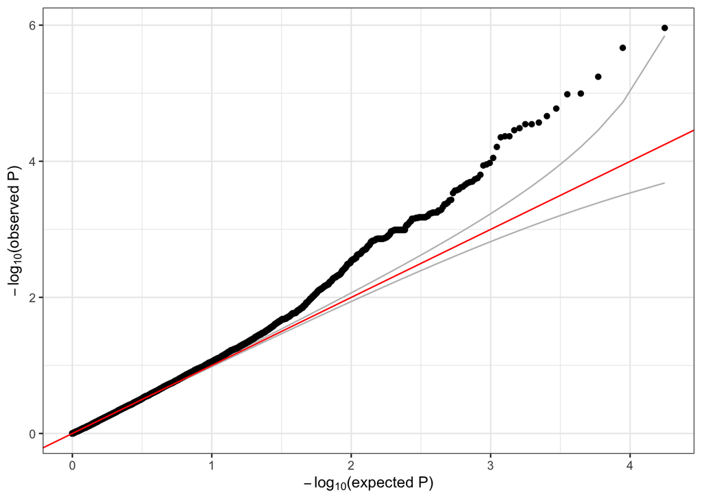

```r
qqPlot <- function(pval) {
    pval <- pval[!is.na(pval)]
    n <- length(pval)
    x <- 1:n
    dat <- data.frame(obs=sort(pval),
                      exp=x/n,
                      upper=qbeta(0.025, x, rev(x)),
                      lower=qbeta(0.975, x, rev(x)))

    ggplot(dat, aes(-log10(exp), -log10(obs))) +
        geom_line(aes(-log10(exp), -log10(upper)), color="gray") +
        geom_line(aes(-log10(exp), -log10(lower)), color="gray") +
        geom_point() +
        geom_abline(intercept=0, slope=1, color="red") +
        xlab(expression(paste(-log[10], "(expected P)"))) +
        ylab(expression(paste(-log[10], "(observed P)"))) +
        theme_bw()
}

# make a QQ plot
qqPlot(assoc$Score.pval[assoc$MAC >= 5])
```

### Fully-Adjusted Two-Stage Model Analysis

Now, let’s run the GWAS using the fully-adjusted two-stage LMM.

#### Null Model

To run the fully-adjusted two-stage null model, we simply set the `two.stage` option to `TRUE`.

```r
# fit the two stage null model
nullmod.twostage <- fitNullModel(annot,
                                 outcome = "trait_2",
                                 covars=c("sex", "age", paste0("PC", c(1:7))),
                                 cov.mat=km,
                                 two.stage = TRUE,
                                 verbose=TRUE)
```

```
## Computing Variance Component Estimates...
```

```
## Sigma^2_A     log-lik     RSS
```

```
## [1]     0.7674395     0.7674395 -1642.1166605     0.9161778
## [1]     0.6850887     0.7089644 -1642.1162960     1.0084433
## [1]     0.6923555     0.7134190 -1642.1162873     1.0000701
```

```
## Computing Variance Component Estimates...
## Sigma^2_A     log-lik     RSS
```

```
## [1]     0.6923555     0.7134190 -1623.4392525     0.9644513
## [1]     0.4614019     0.8850879 -1623.2976713     1.0020121
## [1]     0.4804507     0.8692495 -1623.2964101     1.0000090
## [1]     0.4800435     0.8696570 -1623.2964095     1.0000000
```

Notice that the messages from the function show that the model was fit twice – first with the original outcome and second with the inverse-Normal transformed residuals.

```r
# description of the model we fit
nullmod.twostage$model
```

```
## $hetResid
## [1] FALSE
##
## $family
##
## Family: gaussian
## Link function: identity
##
##
## $outcome
## [1] "trait_2"
##
## $covars
## [1] "sex" "age" "PC1" "PC2" "PC3" "PC4" "PC5" "PC6" "PC7"
##
## $formula
## [1] "rankInvNorm(resid(trait_2)) ~ sex + age + PC1 + PC2 + PC3 + PC4 + PC5 + PC6 + PC7 + (1|A)"
```

From the model description, we can see this is a two stage model because the formula element has `rankInvNorm(resid(trait_2))` as the outcome variable.

#### Association Tests

After fitting the two-stage null model, the association testing procedure is exactly the same. Since we’ve already created our `SeqVarData` iterator, we do not need to create it again; however, we do need to “reset” it to the first block of data.

```r
# reset the filter to the first block
seqResetFilter(iterator, verbose = FALSE)

# run the single-variant association test
assoc.twostage <- assocTestSingle(iterator,
                                  null.model = nullmod.twostage,
                                  test = "Score")
```

```
## # of selected samples: 1,040
```

```r
dim(assoc.twostage)
```

```
## [1] 27621    14
```

We make a QQ plot of all variants with MAC >= 5. What do you notice about this QQ plot compared to the one from the standard null model?

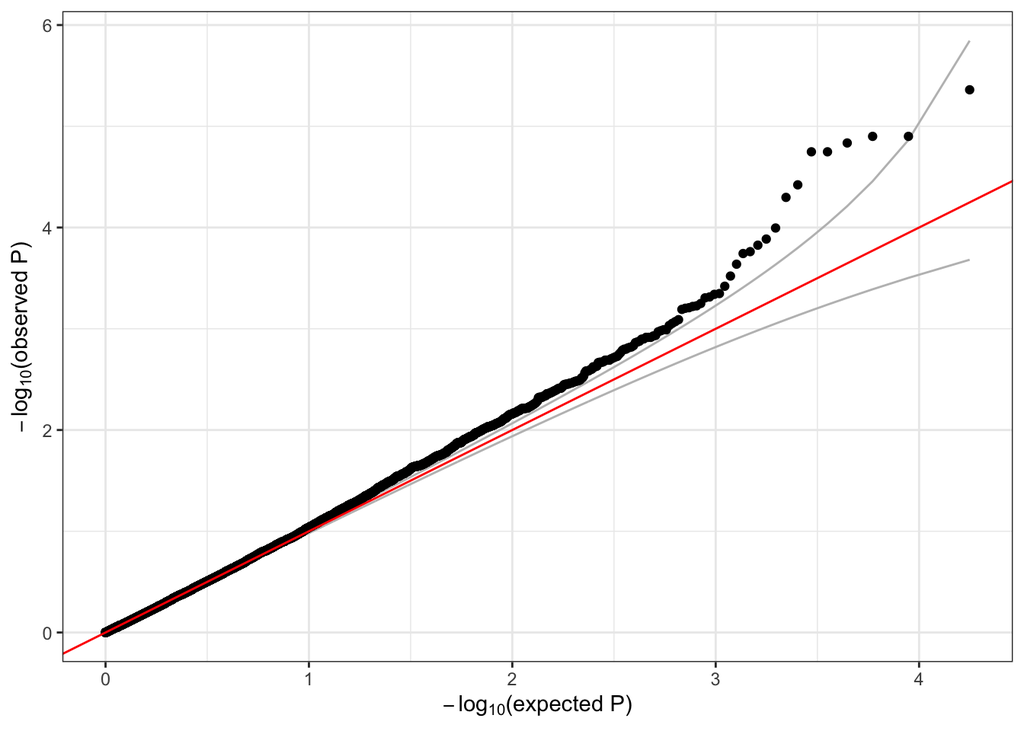

```r
# make a QQ plot
qqPlot(assoc.twostage$Score.pval[assoc.twostage$MAC >= 5])
```

From the QQ plot, we see that using the fully-adjusted two-stage model substantially decreased the amount of inflation in the test statistics. We know that this is because of the non-Normality / skewness of trait_2, but we can compare the marginal residuals from both null models to see how their distributions look after covariate adjustment

```r
# merge the data for plotting
pdat <- merge(nullmod$fit, nullmod.twostage$fit,
              by = 'sample.id', suffixes = c('.orig', '.twostage'))
head(pdat, 2)
```

```
##   sample.id outcome.orig workingY.orig fitted.values.orig resid.marginal.orig
## 1   HG00096          0.1           0.1          0.9522246          -0.8522246
## 2   HG00097          0.1           0.1          0.9098002          -0.8098002
##   resid.conditional.orig linear.predictor.orig resid.PY.orig
## 1             -0.4713968             0.5713968    -0.6607573
## 2             -0.4203074             0.5203074    -0.5891452
##   resid.cholesky.orig outcome.twostage workingY.twostage fitted.values.twostage
## 1          -0.7784371        -1.144867         -1.144867             0.10910933
## 2          -0.6957929        -1.035960         -1.035960             0.08932232
##   resid.marginal.twostage resid.conditional.twostage linear.predictor.twostage
## 1               -1.253977                 -0.8467285                -0.2981388
## 2               -1.125283                 -0.7524428                -0.2835175
##   resid.PY.twostage resid.cholesky.twostage
## 1        -0.9736350               -1.126569
## 2        -0.8652179               -1.002910
```

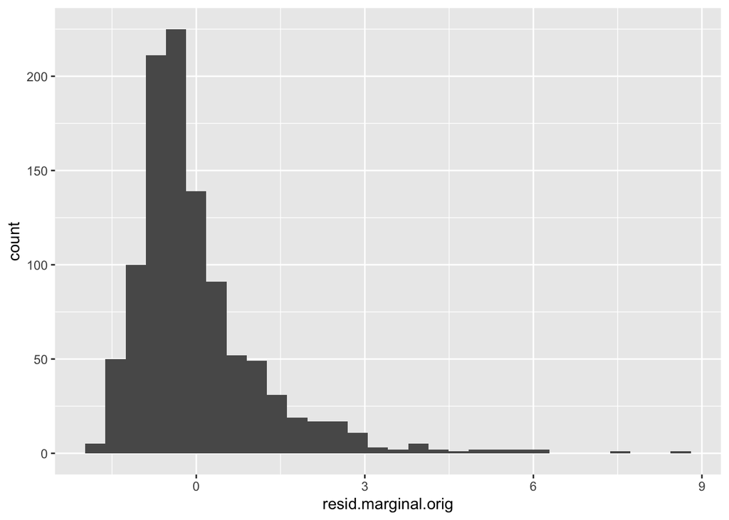

```r
# distribution of residuals - original null model
ggplot(pdat, aes(x = resid.marginal.orig)) + geom_histogram()
```

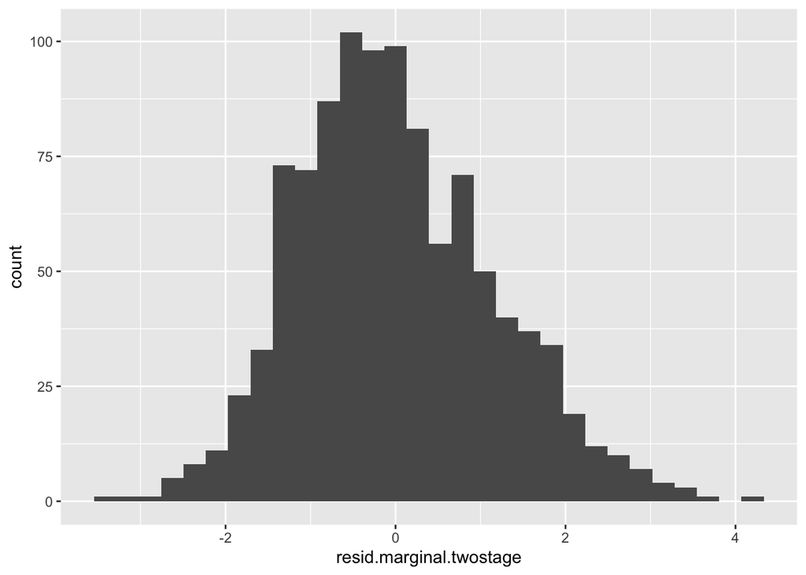

```r
# distribution of residuals - two stage null model
ggplot(pdat, aes(x = resid.marginal.twostage)) + geom_histogram()
```

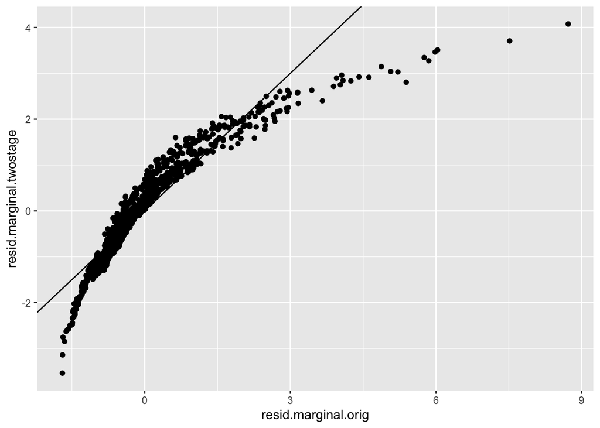

```r
# compare residuals
ggplot(pdat, aes(x = resid.marginal.orig, y = resid.marginal.twostage)) +
    geom_point() +
    geom_abline(intercept = 0, slope = 1)
```

As expected, the residuals from the original model are very skewed, while the residuals from the two-stage model are much closer to Normally distributed. The skewness of the residuals in the original model leads to inflation in variant test statistics (as seen in the QQ plots), particularly for rare or low frequency variants, where effect allele carriers with extreme residuals in the tails of the distribution can have high leverage on the score statistics.

## Binary Traits

GENESIS also supports testing binary (e.g. case/control) outcomes.

### Phenotype Data

The outcome `status` in the annotated phenotype data is a binary case/control variable. Look at the prevalence of this outcome

```r
table(pData(annot)$status)
```

```
##
##   0   1
## 996  44
```

### Logistic Mixed Model Analysis

GENESIS implements the GMMAT method of approximate logistic mixed models for association testing with binary outcomes. See [Chen et al. (2016)](https://www.sciencedirect.com/science/article/pii/S000292971600063X) for more information on the GMMAT method.

#### Null Model

We can fit a null model using a logistic mixed model by specifying the argument `family=binomial` in the `fitNullModel` function. As before, we need to specify the `AnnotatedDataFrame` with the phenotype data (annot), the outcome variable (status), and the fixed effect covariates (sex, age, and PCs 1-7). We still include the kinship matrix to specify the covariance structure of the polygenic random effect in the model.

```r
# fit the null model with logistic mixed model
nullmod.status <- fitNullModel(annot,
                               outcome="status",
                               covars=c("sex", "age", paste0("PC", 1:7)),
                               cov.mat = km,
                               family=binomial,
                               verbose=TRUE)
```

```
## Computing Variance Component Estimates...
```

```
## Sigma^2_A     log-lik     RSS
```

```
## [1]     0.0100000 -3429.7752484     0.8869329
## [1]     0.1904589 -3429.2871878     0.8800663
## [1]     0.1933888 -3429.2794483     0.8799562
```

```
## Updating WorkingY Vector...
```

```
## Computing Variance Component Estimates...
```

```
## Sigma^2_A     log-lik     RSS
```

```
## [1]     0.1933888 -3350.5100738     0.7552805
## [1]     0.1661252 -3350.6802051     0.7563057
## [1]     0.1690691 -3350.6617913     0.7561948
## [1]     0.1687592 -3350.6637295     0.7562065
```

```
## Updating WorkingY Vector...
```

```
## Computing Variance Component Estimates...
```

```
## Sigma^2_A     log-lik     RSS
```

```
## [1]     0.1687592 -3360.7997975     0.7710210
## [1]     0.1778610 -3360.7472975     0.7706784
## [1]     0.1770193 -3360.7521482     0.7707101
```

```
## Updating WorkingY Vector...
```

```
## Computing Variance Component Estimates...
```

```
## Sigma^2_A     log-lik     RSS
```

```
## [1]     0.1770193 -3357.5234919     0.7658698
## [1]     0.1775156 -3357.5205527     0.7658512
```

```
## Updating WorkingY Vector...
```

```
## Computing Variance Component Estimates...
```

```
## Sigma^2_A     log-lik     RSS
```

```
## [1]     0.1775156 -3357.3274708     0.7655623
```

#### Association Tests

After fitting the logistic null model, the association testing procedure is still exactly the same. Since we’ve already created our `SeqVarData` iterator, we do not need to create it again; however, we do need to “reset” it to the first block of data.

```r
# reset the filter to the first block
seqResetFilter(iterator, verbose = FALSE)

# run the single-variant association test
assoc.status <- assocTestSingle(iterator,
                                null.model = nullmod.status,
                                test = "Score")
```

```
## # of selected samples: 1,040
```

```r
dim(assoc.status)
```

```
## [1] 27621    14
```

As usual, we make a QQ plot of all variants with MAC >= 5. What do you notice about the tail of this QQ plot?

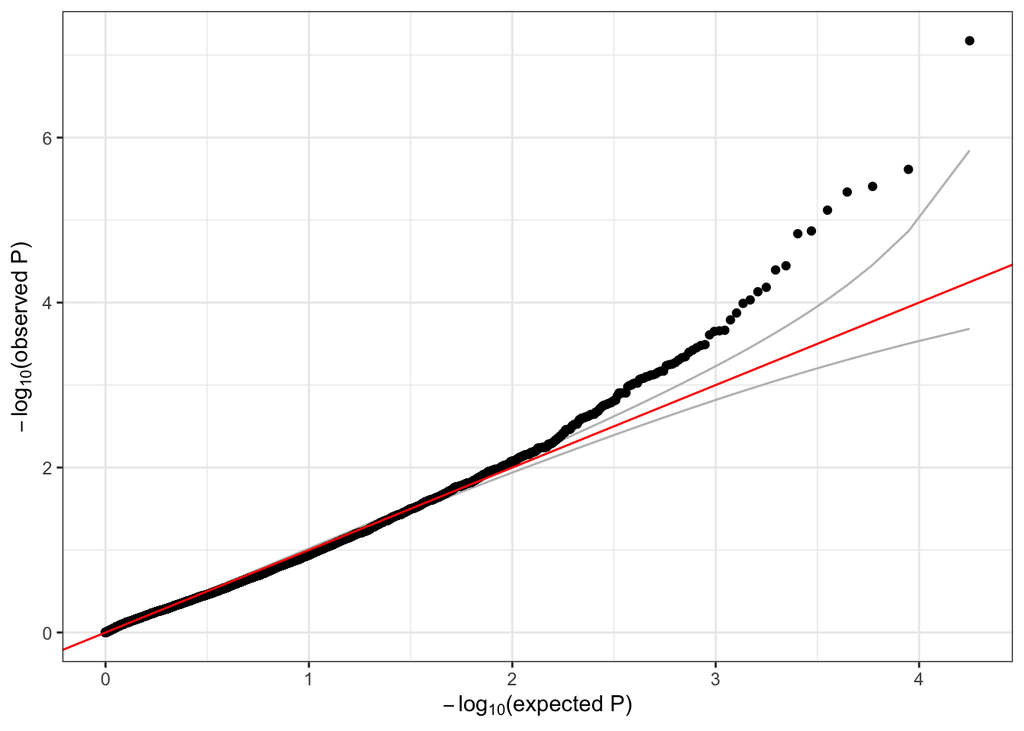

```r
# make a QQ plot
qqPlot(assoc.status$Score.pval[assoc.status$MAC >= 5])
```

#### SPA test

In samples with highly imbalanced case:control ratios, the Score test can be inflated for rare and low frequency variants. Saddlepoint approximation (SPA) can be used to improve $p$-value calculations, and is available in GENESIS by setting the argument `test=Score.SPA` in `assocTestSingle`. See Dey et al. (2017) and [Zhou et al. (2018)](https://www.nature.com/articles/s41588-018-0184-y) for details on using SPA in GWAS. Re-run the analysis using the SPA $p$-value calculation.

```r
# reset the filter to the first block
seqResetFilter(iterator, verbose = FALSE)

# run the single-variant association test
assoc.spa <- assocTestSingle(iterator,
                             null.model = nullmod.status,
                             test = "Score.SPA")
```

```
## # of selected samples: 1,040
```

```r
dim(assoc.spa)
```

```
## [1] 27621    15
```

```r
head(assoc.spa)
```

```
##   variant.id chr    pos allele.index n.obs       freq MAC       Score Score.SE
## 1          1   1 631490            1  1040 0.05576923 116 -0.31231254 1.701762
## 2          2   1 736950            1  1040 0.12067308 251  1.31337450 2.774703
## 3          3   1 800909            1  1040 0.13076923 272 -2.78881539 2.774633
## 4          4   1 814264            1  1040 0.20096154 418  5.93502599 4.447559
## 5          5   1 868735            1  1040 0.92163462 163  0.08006921 2.090673
## 6          6   1 903007            1  1040 0.20817308 433 -2.80060466 3.583768
##    Score.Stat  SPA.pval         Est    Est.SE          PVE SPA.converged
## 1 -0.18352305 0.8543876 -0.10784296 0.5876262 4.271333e-05            NA
## 2  0.47333876 0.6359715  0.17059078 0.3603989 2.841361e-04            NA
## 3 -1.00511162 0.3148431 -0.36225036 0.3604081 1.281182e-03            NA
## 4  1.33444576 0.1820578  0.30004005 0.2248424 2.258313e-03            NA
## 5  0.03829829 0.9694499  0.01831864 0.4783148 1.860120e-06            NA
## 6 -0.78146924 0.4345266 -0.21805797 0.2790359 7.744725e-04            NA
```

Notice that the results of this test include two new columns: `SPA.pval`, which are the $p$-values after the SPA adjustment, and `SPA.converged` which indicates if the SPA adjustment was successful (`TRUE/FALSE`); if the value is `NA` then the SPA adjustment was not applied and the original score test $p$-value is returned – for computational efficiency, SPA is only applied when the original score test $p$-value $< 0.05$. Note that the `Score`, `Score.SE`, and `Score.Stat` are exactly the same for all variants as when using the standard score test, as the SPA adjustment only alters the $p$-value.

```r
table(assoc.spa$SPA.converged, exclude = NULL)
```

```
##
##  TRUE  <NA>
##  1238 26383
```

Make a new QQ plot of all variants with MAC >= 5. How does using the SPA $p$-value adjustment affect the results?

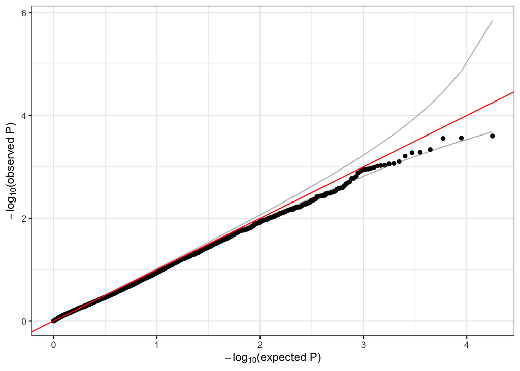

```r
# make a QQ plot
qqPlot(assoc.spa$SPA.pval[assoc.spa$MAC >= 5])
```

Using the SPA $p$-value adjustment has resolved the test statistic inflation!

```r
# close the GDS file!
seqClose(seqData)
```